# *Project - Unplanned stops prediction*

```python
# import arviz as az
import numpy as np
import scipy.stats as stats
import matplotlib.pyplot as plt
import pandas as pd
import seaborn as sns
import arviz as az

from cmdstanpy import CmdStanModel


# GLOBAL CONSTANTS
SEED = 29042020
REFRESH = 1000
BINS = 30
```

## 1. Problem formulation

This project aims to develop predictive models for forecasting unplanned stops in a production process. The prediction of unplanned stops can aid in proactive maintenance planning, resource allocation, and overall optimization of the production process. Two models will be considered: a gamma distribution model and a linear model. These models will utilize two input variables, namely cycle times and production counters, to predict the occurrence and duration of unplanned stops.

The selection of these models is driven by the need to capture different aspects of the relationship between the input variables and the outcome variable of unplanned stops. The gamma distribution model is chosen to account for the non-negativity of the response variable and potential skewness in the data. Conversely, the linear model is chosen to explore the assumption of a linear relationship between the input variables and the response.

The cycle times variable represents the time taken to complete one production cycle, while the production counters variable indicates the number of units produced during a specific period. Both variables are expected to influence the occurrence and duration of unplanned stops. By incorporating these variables into the models, this study aims to understand their impact on unplanned stops and utilize this knowledge to make accurate predictions.

Throughout this project, statistical techniques will be employed, and the Stan modeling language will be used to develop and estimate the parameters of the gamma distribution model and the linear model. Historical data on cycle times, production counters, and corresponding unplanned stops will be used to train the models. Model evaluation and comparison will be performed to assess their predictive performance and identify the model that best captures the relationship between the input variables and the outcome.

The outcomes of this project have the potential to provide valuable insights into the factors affecting unplanned stops in the production process. By accurately predicting these stops, proactive measures can be taken to mitigate their impact, minimize downtime, and improve overall efficiency. The findings can inform decision-making processes related to maintenance planning, resource allocation, and process optimization, ultimately leading to enhanced productivity and cost-effectiveness in the production environment.

### DAG

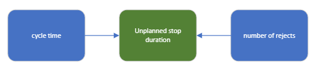

### Confoundings

Confounding refers to a situation where the relationship between the predictor variables (independent variables) and the response variable (dependent variable) is influenced or distorted by the presence of an additional variable, known as a confounding variable. In the context of the gamma distribution and linear models for predicting unplanned stops using cycle times and production counters, it is important to consider the potential confounding factors that may impact the relationship.

One potential confounding factor in this scenario could be the effect of other external factors or variables that influence both the cycle times, production counters, and the occurrence of unplanned stops. These confounding variables might include factors such as equipment reliability, environmental conditions, operator skill levels, or changes in production processes.

In the context of the described models for predicting unplanned stops using cycle times and production counters, it is important to consider the potential types of confounding that may be present. Let's examine three types of confounding: pipe confounding, fork confounding, and collider confounding.

1. Pipe Confounding: Pipe confounding occurs when a variable lies on the causal pathway between the predictor variables and the outcome variable. In this scenario, a variable, let's say "equipment reliability," could act as a pipe confounder. It influences both the cycle times and the occurrence of unplanned stops. For example, if the equipment is unreliable, it can lead to longer cycle times and a higher likelihood of unplanned stops. If "equipment reliability" is not accounted for in the models, it can introduce confounding and bias the relationship between the predictor variables and unplanned stops.
2. Fork Confounding: Fork confounding arises when two distinct causes affect both the predictor variables and the outcome variable independently. In this case, an external factor such as "environmental conditions" could act as a fork confounder. For instance, extreme temperature or humidity can affect both cycle times and the occurrence of unplanned stops. If "environmental conditions" are not considered as a confounding variable, it may lead to spurious associations or distorted effects of the predictor variables on unplanned stops.
3. Collider Confounding: Collider confounding occurs when the predictor variables are influenced by a common effect, leading to a spurious association between them. For instance, a variable such as "operator skill level" might act as a collider. If highly skilled operators tend to work on specific production runs with longer cycle times, and those specific runs also have a higher likelihood of experiencing unplanned stops, it can create a collider scenario. If the models do not account for "operator skill level" as a confounding variable, it may lead to misleading or biased estimates of the relationship between cycle times, production counters, and unplanned stops.

## 2. Data preprocessing

Data used to this project came from the factory's MES system in form of three CSV files:

- states.csv,
- counters.csv,
- cycle_times.csv

that contain information about production counters, line's states during production runtime and produced items' cycle times for March and a part of April. CSV files have been prepared using SQL queries to the MES database.

There has been applied a division into the equal time windows (6 hours), in which unplanned stops times, production counters and cycle times are analysed. This particular length of the time window corresponds to the half of the production shift and provides the proper data granularity.

```python
START_DATETIME, END_DATETIME = pd.to_datetime("2022-03-04 18:00:00 +01:00"), pd.to_datetime("2022-04-06 06:00:00+01:00")
START_DATETIME_BREAK, END_DATETIME_BREAK = pd.to_datetime("2022-03-29 06:00:00+01:00"), pd.to_datetime("2022-04-02 06:00:00+01:00")
```

### States

States' data consists of 4 columns:

- state id,
- start time,
- end time,
- state tag (can be RUN, MICROSTOP, UNPLANNED STOP and many more).

Data is filtered so it contains only RUN state and unscheduled stoppages.

```python
states_df = pd.read_csv('states.csv', delimiter=';')
states_map = {'RUN': 1}
states_df.head()
```

|  | id | time_from | time_to | tag |
| --- | --- | --- | --- | --- |
| 0 | 6312581 | 2022-03-04 09:18:19 +01:00 | 2022-03-04 09:18:48 +01:00 | RUN |
| 1 | 6312619 | 2022-03-04 09:20:04 +01:00 | 2022-03-04 09:20:41 +01:00 | RUN |
| 2 | 6312655 | 2022-03-04 09:21:51 +01:00 | 2022-03-04 09:23:02 +01:00 | RUN |
| 3 | 6313787 | 2022-03-04 09:30:17 +01:00 | 2022-03-04 10:25:31 +01:00 | RUN |
| 4 | 6313869 | 2022-03-04 10:27:54 +01:00 | 2022-03-04 10:28:13 +01:00 | RUN |

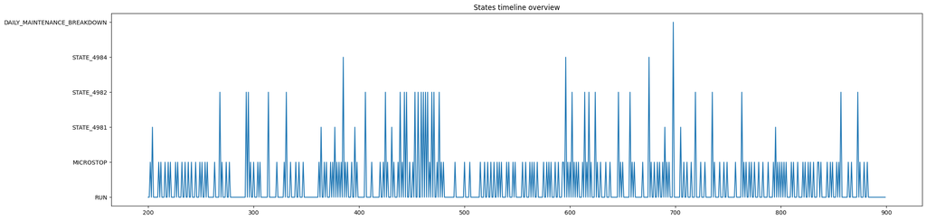

```python
plt.figure(figsize=(25, 6))
plt.title('States timeline overview')
plt.plot(states_df['tag'][200:900])
plt.show()
```

```python
df = states_df.copy()
df['time_from_dt'] = pd.to_datetime(df['time_from'])
df['time_to_dt'] = pd.to_datetime(df['time_to'])

t1 = START_DATETIME
i = 0
n = 0
data_states = {}
last_period = None

while True:
    t1 = START_DATETIME + pd.DateOffset(hours=6 * i)
    t2 = START_DATETIME + pd.DateOffset(hours=6 * (i + 1))

    if t1 > END_DATETIME: break

    if t1 > START_DATETIME_BREAK and t1 < END_DATETIME_BREAK:
        i += 1
        continue

    period = df.copy()
    period = period[period["time_from_dt"] >= t1]
    period = period[period["time_from_dt"] < t2]

    if len(period) > 0:
        period["period_end_dt"] = t2
        period["state_end_dt"] = period[['time_to_dt', 'period_end_dt']].min(axis=1)
        period["interval"] = period["state_end_dt"].apply(lambda x: x.timestamp()) - period["time_from_dt"].apply(lambda x: x.timestamp())
        interval = period["interval"].sum()
        unplanned_stop_time = period[period["tag"] != "RUN"]["interval"].sum()
        last_period = period

    else:
        time_from_dt, time_to_dt, period_end_dt, tag = last_period.iloc[-1]["time_from_dt"], last_period.iloc[-1]["time_to_dt"], last_period.iloc[-1]["period_end_dt"], last_period.iloc[-1]["tag"]
        state_end_dt = min([time_to_dt, period_end_dt])
        interval = state_end_dt.timestamp() - time_from_dt.timestamp()
        unplanned_stop_time = 0 if tag == "RUN" else interval

    data_states[n + 1] = unplanned_stop_time / interval
    i += 1
    n += 1

print(data_states)
```

```
{1: 0.010844516741222719, 2: 0.0003084832904884319, 3: 0.0060880153070099145, 4: 0.011596946926217384, 5: 0.01948765396403169, 6: 0.008104073363190446, 7: 0.014564831261101243, 8: 0.012224675534492972, 9: 0.01012130108939195, 10: 0.006129641926750779, 11: 0.009423924608603132, 12: 0.0031279673797687…
```

### Counters

Counters table contains information about production quantity grouped by production hours, there are two types of counters:

- PRODUCTION (amount of good pieces),
- REJECT (production waste)

```python
counters_df = pd.read_csv('counters.csv', delimiter=';')
counters_df.head()
```

|  | id | value | prod_hour | tag |
| --- | --- | --- | --- | --- |
| 0 | 30738538 | 54.000 | 2022-03-04 09:00:00 +01:00 | PRODUCTION |
| 1 | 30739005 | 50.333 | 2022-03-04 09:00:00 +01:00 | REJECT |
| 2 | 30738341 | 33.000 | 2022-03-04 09:00:00 +01:00 | PRODUCTION |
| 3 | 30739158 | 36.333 | 2022-03-04 09:00:00 +01:00 | REJECT |
| 4 | 30738658 | 60.000 | 2022-03-04 09:00:00 +01:00 | PRODUCTION |

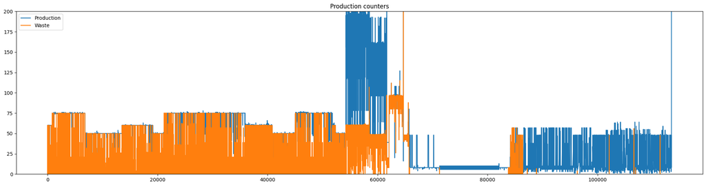

```python
plt.figure(figsize=(25, 6))
plt.title('Production counters')
plt.plot((counters_df.loc[counters_df['tag']=='PRODUCTION'])['value'], label='Production')
plt.plot((counters_df.loc[counters_df['tag']=='REJECT'])['value'], label='Waste')
plt.ylim([0, 200])
plt.legend()
plt.show()
```

```python
df = counters_df.copy()
df['prod_hour_dt'] = pd.to_datetime(df['prod_hour'])
data_counters = {}
t1 = START_DATETIME
i = 0
n = 0
last_period = None

while True:
    t1 = START_DATETIME + pd.DateOffset(hours=6 * i)
    t2 = START_DATETIME + pd.DateOffset(hours=6 * (i + 1))

    if t1 > END_DATETIME: break

    if t1 > START_DATETIME_BREAK and t1 < END_DATETIME_BREAK:
        i += 1
        continue

    period = df.copy()
    period = period[period["prod_hour_dt"] >= t1]
    period = period[period["prod_hour_dt"] < t2]
    data_counters[n + 1] = period["value"].sum()
    i += 1
    n += 1

print(data_counters)
```

```
{1: 9985.5, 2: 23695.0, 3: 23308.5, 4: 22002.5, 5: 21815.5, 6: 25687.5, 7: 24778.0, 8: 21917.0, 9: 16571.5, 10: 24083.5, 11: 5742.0, 12: 16729.0, 13: 16703.0, 14: 11961.0, 15: 13784.0, 16: 15980.0, 17: 17258.0, 18: 17677.0, 19: 12923.0, 20: 16822.0, 21: 18078.0, 22: 13744.0, 23: 14827.0, 24: 19480.0…
```

### Cycle times

Third file stores information about items' cycle times from which target speed can be calculated simply. Production orders' duration is provided here as well.

```python
cycle_times_df = pd.read_csv('cycle_times.csv', delimiter=';')
cycle_times_df.head()
```

|  | start_time | end_time | cycle_time_s |
| --- | --- | --- | --- |
| 0 | 2022-03-04 20:20:20 +01:00 | 2022-03-06 17:58:55 +01:00 | 0.8 |
| 1 | 2022-03-06 17:59:33 +01:00 | 2022-03-07 05:31:12 +01:00 | 0.8 |
| 2 | 2022-03-07 09:35:57 +01:00 | 2022-03-08 03:33:14 +01:00 | 1.2 |
| 3 | 2022-03-08 05:30:54 +01:00 | 2022-03-08 06:18:19 +01:00 | 1.2 |
| 4 | 2022-03-08 06:18:56 +01:00 | 2022-03-09 07:16:36 +01:00 | 1.2 |

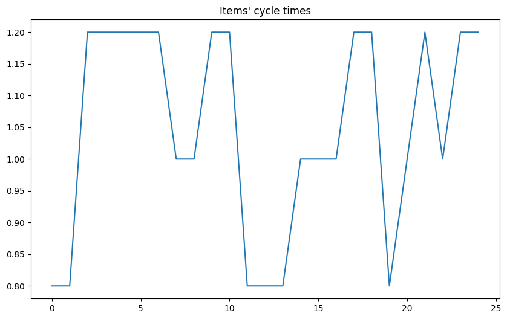

```python
plt.figure(figsize=(10, 6))
plt.title('Items\' cycle times')
plt.plot(cycle_times_df['cycle_time_s'])
plt.show()
```

```python
df = cycle_times_df.copy()
df['start_time_dt'] = pd.to_datetime(df['start_time'])
df['start_time_ts'] = df['start_time_dt'].apply(lambda x: x.timestamp())
data_cycles = {}
t1 = START_DATETIME
i = 0
n = 0

while True:
    t1 = START_DATETIME + pd.DateOffset(hours=6 * i)
    t2 = START_DATETIME + pd.DateOffset(hours=6 * (i + 1))

    if t1 > END_DATETIME: break

    if t1 > START_DATETIME_BREAK and t1 < END_DATETIME_BREAK:
        i += 1
        continue

    period = df.copy()
    period = period[period["start_time_dt"] >= t1]
    period = period[period["start_time_dt"] < t2]

    if len(period) > 0:
        weights = []
        cycle_time = 0

        for idx in range(len(period)):
            if idx == len(period) - 1:
                weight = t2.timestamp() - period.iloc[idx]["start_time_ts"]

            else:
                weight = period.iloc[idx + 1]["start_time_ts"] - period.iloc[idx]["start_time_ts"]

            weights.append(weight)
            time = period.iloc[idx]["cycle_time_s"]
            cycle_time = cycle_time + weight * time

        data_cycles[n + 1] = cycle_time / sum(weights)

    else:
        data_cycles[n + 1] = data_cycles[n]

    i += 1
    n += 1

print(data_cycles)
```

```
{1: 0.8, 2: 0.8, 3: 0.8, 4: 0.8, 5: 0.8, 6: 0.8, 7: 0.8, 8: 0.8, 9: 0.8, 10: 0.8, 11: 1.2, 12: 1.2, 13: 1.2, 14: 1.2, 15: 1.2, 16: 1.2, 17: 1.2, 18: 1.2, 19: 1.2, 20: 1.2, 21: 1.2, 22: 1.0, 23: 1.0, 24: 1.0, 25: 1.0, 26: 1.0, 27: 1.0, 28: 1.0, 29: 1.0, 30: 1.0, 31: 1.2, 32: 1.2, 33: 1.2, 34: 1.2, 35…
```

### Omitting empty values

```python
data_states_list = []
data_counters_list = []
data_cycles_list = []

for i in data_states:
    if data_states[i] > 0 and data_counters[i] > 0 and data_cycles[i] > 0:
        data_states_list.append(data_states[i])
        data_counters_list.append(data_counters[i])
        data_cycles_list.append(data_cycles[i])
```

## 3. Model

### Models specification

It takes into account a linear relationship between unplanned stops and cycle times. If provides simplicity, interpretability and clear understanding of the relationship.

It also takes into account a linear relationship between unplanned stops and cycle times, but takes into consideration production counters as well. Gamma distribution provides non-negativity as there is need for predicted values to be non-negative. The gamma distribution is suitable for modeling positive continuous variables, such as durations. The gamma distribution allows for capturing the distributional characteristics of the data, particularly the right-skewness typically observed in duration or time-to-event data.

### Difference between models

Both models may evaluate the impact of these variables on unplanned stops durations.

### Difference between models justification

Such specified models will be a perfect study object since the only difference between them is in the fact if the production counters have been taken into consideration. From the theoretical point of view, it makes sense to take this variable into account since the number of rejects is correlated with unplanned stops.

### Models description

Input data

- number of samples,
- unplanned stops times,
- number of rejects (used only in Model 2),
- cycle times,
- gamma and exponential distribution priors.

Parameters ($\alpha$, $\beta$ and optionally $\gamma$):

- coefficients of linear model,
- parameters of distributions.

## 4. Prior predictive checks for model 1 (Gamma)

Gamma distribution was chosen to model and predict unplanned stops because it aligns well with the characteristics and assumptions of the problem at hand. The decision to use a gamma distribution is based on the following considerations:

1. Non-Negative Predictions: It is essential to ensure that the predicted unplanned stop times are non-negative since they represent durations or quantities that cannot be negative. The gamma distribution is well-suited for this purpose as it has support for positive values only, ensuring that the predicted values are realistic and within the appropriate range.
2. Flexibility and Skewness: The gamma distribution is a versatile and widely used probability distribution for modeling positive continuous data. It can capture a wide range of shapes and allows for right-skewness, which is often observed in duration or time-to-event data. By using the gamma distribution, it is possible to effectively capture the distributional characteristics of the unplanned stop times and account for potential skewness in the data.
3. Interpretability: The parameters of the gamma distribution have meaningful interpretations. The shape parameter controls the shape of the distribution, while the scale parameter determines the overall scale or average unplanned stop time.
4. Validating Assumptions: By choosing the gamma distribution, it is assumed that the unplanned stop times follow a specific distributional form. This assumption can be further assessed and validated through model evaluation and diagnostic procedures. If the gamma distribution is found to be a good fit for the data, it provides confidence in the modeling approach and enhances the reliability of the predictions.

By considering the non-negativity of the response variable, the flexibility and skewness-capturing capability of the gamma distribution, as well as the interpretability of its parameters, we can construct a robust and appropriate model for predicting unplanned stops.

```python
gamma_ppc = CmdStanModel(stan_file="gamma_ppc.stan")
```

```
15:13:07 - cmdstanpy - INFO - compiling stan file C:\Users\gcyburt\Documents\repos\priv\AGH-Data-Analytics\Data-Analytics\Project\gamma_ppc.stan to exe file C:\Users\gcyburt\Documents\repos\priv\AGH-Data-Analytics\Data-Analytics\Project\gamma_ppc.exe
15:13:27 - cmdstanpy - INFO - compiled model executable: C:\Users\gcyburt\Documents\repos\priv\AGH-Data-Analytics\Data-Analytics\Project\gamma_ppc.exe
```

```
15:13:28 - cmdstanpy - INFO - CmdStan start processing
chain 1 |██████████| 00:00 Sampling completed
```

[output not shown]

[output cut: 80 more lines]

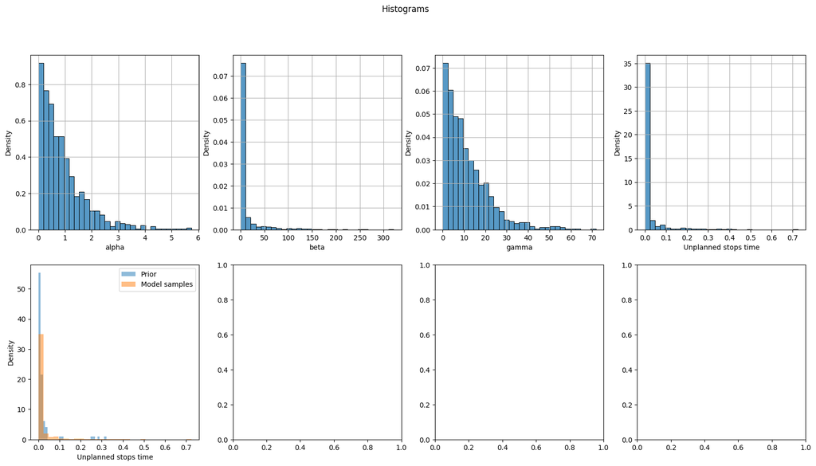

```python
gamma_ppc_data = {"N": len(data_states_list), "rejects": data_counters_list, "cycle_times": data_cycles_list,
                  "alpha_shape": 1, "alpha_scale": 1, "beta_shape": 0.1, "beta_scale": 0.01, "gamma_shape": 1, "gamma_scale": 0.1}
gamma_ppc_sim = gamma_ppc.sample(data=gamma_ppc_data, iter_sampling=REFRESH, iter_warmup=0, chains=1, fixed_param=True, seed=SEED)
gamma_ppc_df = gamma_ppc_sim.draws_pd()

_, ax = plt.subplots(2, 4, figsize=(20, 10))
ax = ax.flatten()
sns.histplot(data=gamma_ppc_df, x="alpha", stat="density", ax=ax[0], bins=BINS)
sns.histplot(data=gamma_ppc_df, x="beta", stat="density", ax=ax[1], bins=BINS)
sns.histplot(data=gamma_ppc_df, x="gamma", stat="density", ax=ax[2], bins=BINS)
sns.histplot(data=gamma_ppc_df, x="predicted_stop_times[1]", stat="density", ax=ax[3], bins=BINS)
ax[4].hist(data_states_list, bins=BINS, alpha=0.5, density=True, label="Prior")
ax[4].hist(gamma_ppc_df["predicted_stop_times[1]"], bins=BINS, alpha=0.5, density=True, label="Model samples")
ax[0].grid(), ax[1].grid(), ax[2].grid(), ax[3].grid()
ax[0].set_xlabel("alpha"), ax[1].set_xlabel("beta"), ax[2].set_xlabel("gamma"), ax[3].set_xlabel("Unplanned stops time"), ax[4].set_xlabel("Unplanned stops time")
ax[4].set_ylabel("Density")
ax[4].legend()
plt.suptitle("Histograms")
plt.show()
```

Prior parameters were chosen half-empirically. There have applied standard (from literature) parameters such as shape=1 and scale=1 for gamma distribution. Then there have been being modified to obtain the data similar to the observed one.

The chosen parameters make it possible to obtain the observed data.

## 4. Fitting and evaluating model 1 (Gamma)

```python
gamma_fit = CmdStanModel(stan_file="gamma_fit.stan")
```

```
15:13:30 - cmdstanpy - INFO - compiling stan file C:\Users\gcyburt\Documents\repos\priv\AGH-Data-Analytics\Data-Analytics\Project\gamma_fit.stan to exe file C:\Users\gcyburt\Documents\repos\priv\AGH-Data-Analytics\Data-Analytics\Project\gamma_fit.exe
15:13:51 - cmdstanpy - INFO - compiled model executable: C:\Users\gcyburt\Documents\repos\priv\AGH-Data-Analytics\Data-Analytics\Project\gamma_fit.exe
```

[output not shown]

[output not shown]

[output cut: 15 more lines]

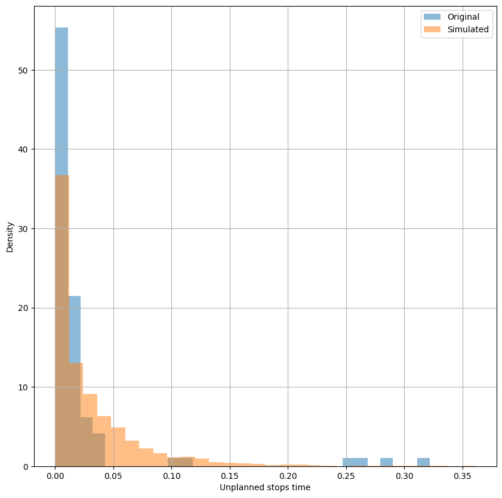

```python
gamma_fit_data = {"N": len(data_states_list), "unplanned_stop_times": data_states_list, "rejects": data_counters_list, "cycle_times": data_cycles_list,
                  "alpha_shape": 1, "alpha_scale": 1, "beta_shape": 0.1, "beta_scale": 0.01, "gamma_shape": 1, "gamma_scale": 0.1}
gamma_fit_sim = gamma_fit.sample(data=gamma_fit_data, seed=SEED)
gamma_fit_df = gamma_fit_sim.draws_pd()

plt.figure(figsize=(10, 10))
plt.hist(data_states_list, bins=BINS, alpha=0.5, density=True, label="Original")
plt.hist(gamma_fit_df["predicted_stop_times[1]"], bins=BINS, alpha=0.5, density=True, label="Simulated")
plt.xlabel("Unplanned stops time"), plt.ylabel("Density")
plt.grid()
plt.legend()
plt.show()
```

### Fit summary

```python
summary = gamma_fit_sim.summary()
summary.head(6)
```

|  | Mean | MCSE | StdDev | 5% | 50% | 95% | N_Eff | N_Eff/s | R_hat |
| --- | --- | --- | --- | --- | --- | --- | --- | --- | --- |
| lp__ | 249.725000 | 5.716340e-02 | 1.407850 | 2.469750e+02 | 2.500740e+02 | 251.315000 | 606.566 | 169.479 | 1.002570 |
| alpha | 0.591835 | 2.529290e-03 | 0.071851 | 4.816530e-01 | 5.864610e-01 | 0.720605 | 807.004 | 225.483 | 1.009610 |
| beta | 0.000002 | 1.472200e-07 | 0.000006 | 6.768970e-19 | 1.594820e-08 | 0.000012 | 1705.190 | 476.443 | 1.001810 |
| gamma | 24.094900 | 1.511080e-01 | 4.417560 | 1.727590e+01 | 2.370760e+01 | 31.567600 | 854.654 | 238.797 | 1.004110 |
| predicted_stop_times[1] | 0.030701 | 6.435300e-04 | 0.040020 | 2.443780e-04 | 1.570500e-02 | 0.112782 | 3867.350 | 1080.570 | 0.999317 |
| predicted_stop_times[2] | 0.031968 | 7.035250e-04 | 0.043155 | 2.559570e-04 | 1.617250e-02 | 0.116721 | 3762.780 | 1051.350 | 0.999288 |

### Marginal distributions

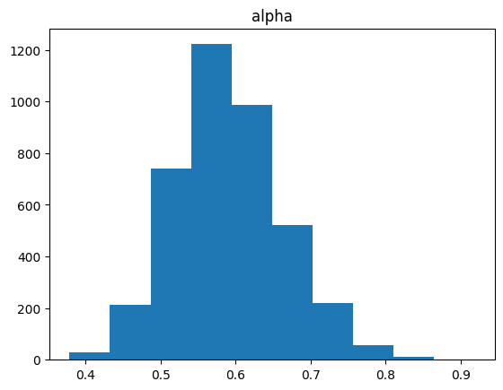

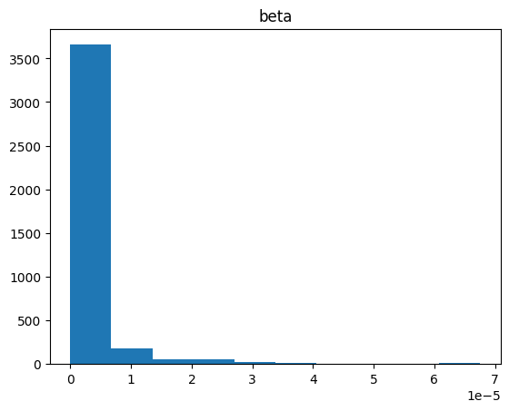

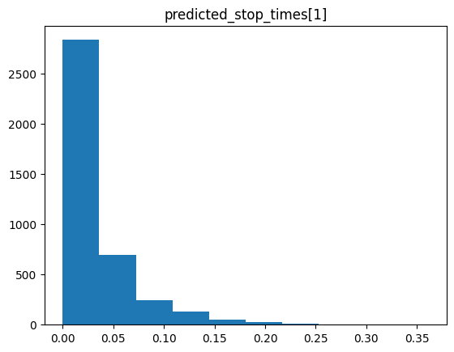

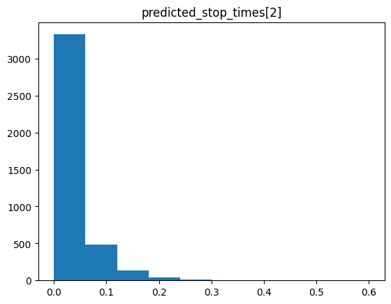

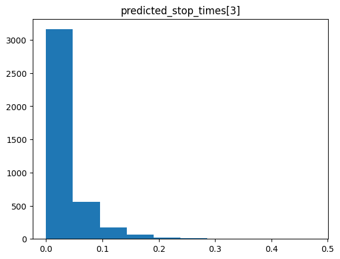

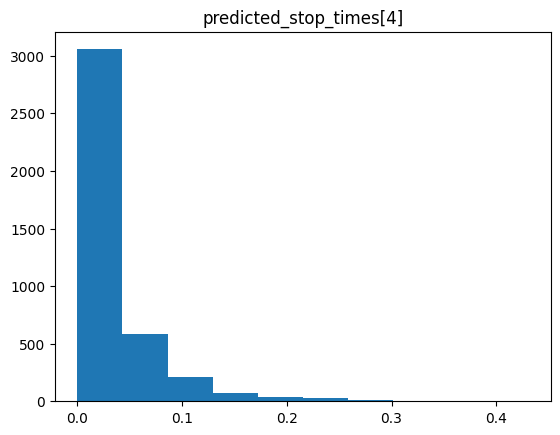

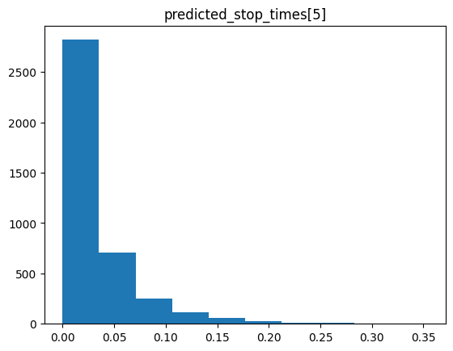

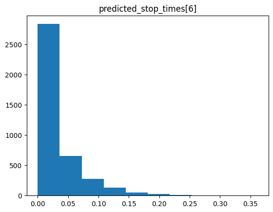

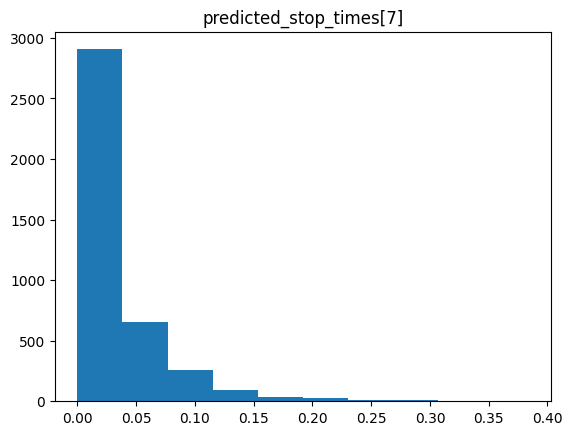

```python
for parameter in ['alpha', 'beta', 'predicted_stop_times[1]', 'predicted_stop_times[2]', 'predicted_stop_times[3]',
               'predicted_stop_times[4]', 'predicted_stop_times[5]', 'predicted_stop_times[6]', 'predicted_stop_times[7]']:
   plt.hist(gamma_fit_df[parameter])
   plt.title(parameter)
   plt.show()
```

## 5. Prior predictive checks for model 2 (linear)

Linear model was chosen to predict unplanned stops because it aligns with the assumptions and characteristics of the problem at hand. The decision to use a linear model is based on the following considerations:

1. Simplicity and Interpretability: A linear model provides a straightforward and interpretable relationship between the predictor variable ("cycle time") and the output of the designed system. The coefficients in the linear model have direct interpretations: the intercept represents the expected unplanned stop time when the cycle time is zero, and the slope represents the change in the expected unplanned stop time per unit increase in the cycle time. This simplicity allows for easy understanding and communication of the results.
2. Linearity Assumption: assumptionhas been made that the relationship between cycle time and unplanned stops is linear. While this assumption may not hold in all cases, it is reasonable to assume linearity when there is no strong evidence or prior knowledge suggesting a non-linear relationship. By assuming linearity, the linear model captures the overall trend and direction of the relationship.
3. Availability and Implementation: Linear models are widely implemented and available in various statistical software packages. They are computationally efficient and can handle large datasets. This availability and ease of implementation make linear models a practical choice, allowing to quickly analyze and interpret the relationship between the variables.
4. Initial Exploration: Using a linear model serves as an initial exploration to understand the basic relationship between cycle time and unplanned stops. It provides a foundation for further analysis and model refinement. If the linear model reveals a meaningful relationship and performs adequately, it can provide valuable insights and guide decision-making.
5. It's important to acknowledge that a linear model might not capture all the complexities or non-linear relationships that exist in the data. If there are indications or prior knowledge suggesting non-linear patterns, alternative modeling approaches such as polynomial regression, splines, or machine learning algorithms may be more appropriate. However, the linear model serves as a reasonable starting point to understand the relationship between cycle time and unplanned stops and can provide valuable insights within its assumptions and limitations.

```python
exp_ppc = CmdStanModel(stan_file="exp_ppc.stan")
```

```
15:14:00 - cmdstanpy - INFO - compiling stan file C:\Users\gcyburt\Documents\repos\priv\AGH-Data-Analytics\Data-Analytics\Project\exp_ppc.stan to exe file C:\Users\gcyburt\Documents\repos\priv\AGH-Data-Analytics\Data-Analytics\Project\exp_ppc.exe
15:14:21 - cmdstanpy - INFO - compiled model executable: C:\Users\gcyburt\Documents\repos\priv\AGH-Data-Analytics\Data-Analytics\Project\exp_ppc.exe
```

```
15:14:22 - cmdstanpy - INFO - CmdStan start processing
chain 1 |██████████| 00:00 Sampling completed
```

```
15:14:22 - cmdstanpy - INFO - CmdStan done processing.
```

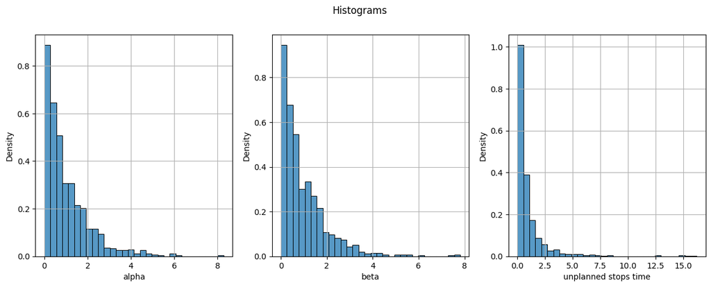

```python
exp_ppc_data = {"N": len(data_states_list), "cycle_times": data_cycles_list}
exp_ppc_sim = exp_ppc.sample(data=exp_ppc_data, iter_sampling=REFRESH, iter_warmup=0, chains=1, refresh=REFRESH, fixed_param=True, seed=SEED)
exp_ppc_df = exp_ppc_sim.draws_pd()

_, ax = plt.subplots(1, 3, figsize=(15, 5))
sns.histplot(data=exp_ppc_df, x="alpha", stat="density", ax=ax[0], bins=BINS)
sns.histplot(data=exp_ppc_df, x="beta", stat="density", ax=ax[1], bins=BINS)
sns.histplot(data=exp_ppc_df, x="predicted_stop_times[1]", stat="density", ax=ax[2], bins=BINS)
ax[0].grid(), ax[1].grid(), ax[2].grid()
ax[0].set_xlabel("alpha"), ax[1].set_xlabel("beta"), ax[2].set_xlabel("unplanned stops time")
plt.suptitle("Histograms")
plt.show()
```

Prior parameters were chosen half-empirically. There has applied standard (from literature) parameter for exponential distribution. Then there has been being modified to obtain the data similar to the observed one.

The chosen parameters make it possible to obtain the observed data.

## 6. Fitting and evaluating model 2 (linear)

```python
exp_fit = CmdStanModel(stan_file="exp_fit.stan")
```

```
15:14:23 - cmdstanpy - INFO - compiling stan file C:\Users\gcyburt\Documents\repos\priv\AGH-Data-Analytics\Data-Analytics\Project\exp_fit.stan to exe file C:\Users\gcyburt\Documents\repos\priv\AGH-Data-Analytics\Data-Analytics\Project\exp_fit.exe
15:14:43 - cmdstanpy - INFO - compiled model executable: C:\Users\gcyburt\Documents\repos\priv\AGH-Data-Analytics\Data-Analytics\Project\exp_fit.exe
```

[output not shown]

```
15:14:45 - cmdstanpy - INFO - CmdStan done processing.
15:14:45 - cmdstanpy - WARNING - Non-fatal error during sampling:
Exception: exponential_lpdf: Inverse scale parameter is inf, but must be positive finite! (in 'C:/Users/gcyburt/Documents/repos/priv/AGH-Data-Analytics/Data-Analytics/Project/exp_fit.stan', line 19, column 4 to column 74)
Consider re-running with show_console=True if the above output is unclear!
15:14:45 - cmdstanpy - WARNING - Some chains may have failed to converge.
	Chain 2 had 3 divergent transitions (0.3%)
	Chain 4 had 9 divergent transitions (0.9%)
	Use function "diagnose()" to see further information.
```

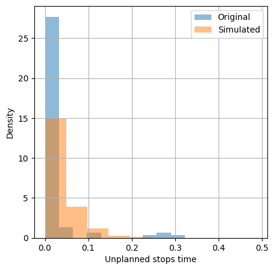

```python
exp_fit_data = {"N": len(data_states_list), "unplanned_stops_times": data_states_list, "cycle_times": data_cycles_list}
exp_fit_sim = exp_fit.sample(data=exp_fit_data, seed=SEED)
exp_fit_df = exp_fit_sim.draws_pd()

plt.figure(figsize=(5, 5))
plt.hist(data_states_list, bins=10, alpha=0.5, density=True, label="Original")
plt.hist(exp_fit_df["predicted_stop_times[1]"], bins=10, alpha=0.5, density=True, label="Simulated")
plt.grid()
plt.xlabel("Unplanned stops time"), plt.ylabel("Density")
plt.legend()
plt.show()
```

### Fit summary

```python
summary = exp_fit_sim.summary()
summary.head(6)
```

|  | Mean | MCSE | StdDev | 5% | 50% | 95% | N_Eff | N_Eff/s | R_hat |
| --- | --- | --- | --- | --- | --- | --- | --- | --- | --- |
| lp__ | 215.751000 | 0.096002 | 1.229790 | 213.200000 | 216.144000 | 216.932000 | 164.0980 | 58.9219 | 1.040890 |
| alpha | 19.344200 | 0.836074 | 7.597620 | 4.470560 | 20.684300 | 30.015000 | 82.5783 | 29.6511 | 1.077820 |
| beta | 9.440480 | 0.769211 | 7.360450 | 0.579812 | 7.671010 | 24.336100 | 91.5625 | 32.8770 | 1.077740 |
| predicted_stop_times[1] | 0.037707 | 0.000655 | 0.039800 | 0.001722 | 0.025276 | 0.114448 | 3689.8000 | 1324.8800 | 0.999694 |
| predicted_stop_times[2] | 0.038002 | 0.000618 | 0.038779 | 0.002030 | 0.026079 | 0.112449 | 3942.9600 | 1415.7800 | 0.999935 |
| predicted_stop_times[3] | 0.039439 | 0.000659 | 0.039586 | 0.001890 | 0.027160 | 0.116857 | 3606.6800 | 1295.0400 | 1.001320 |

### Marginal distributions

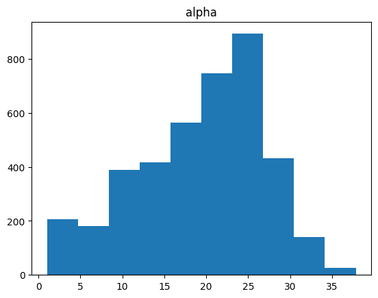

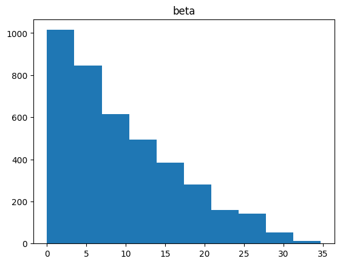

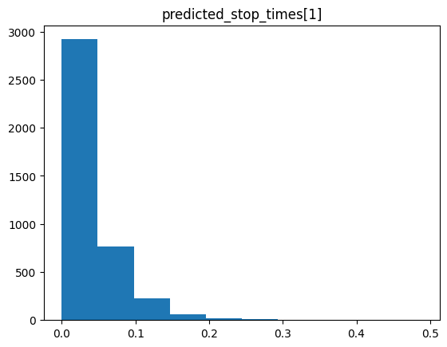

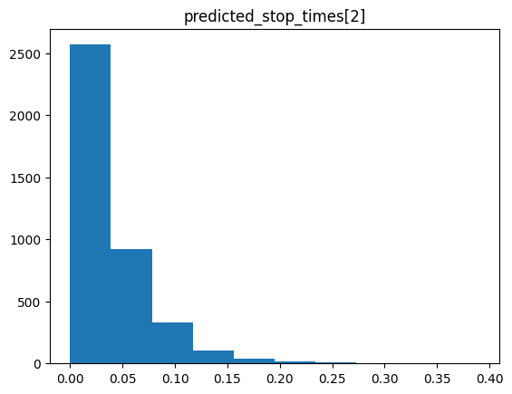

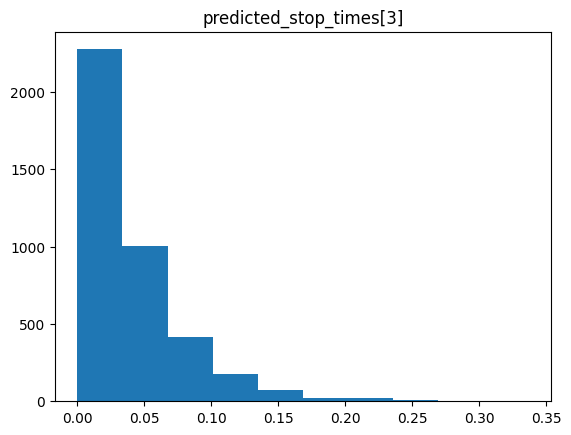

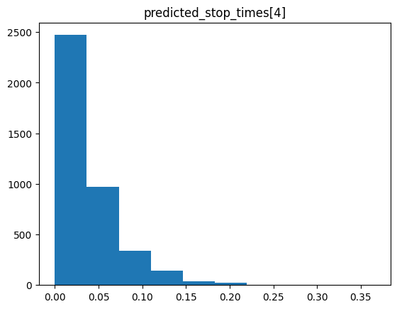

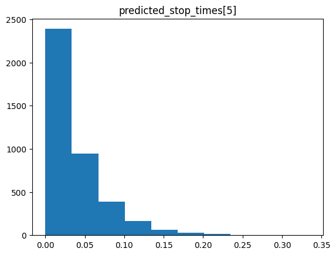

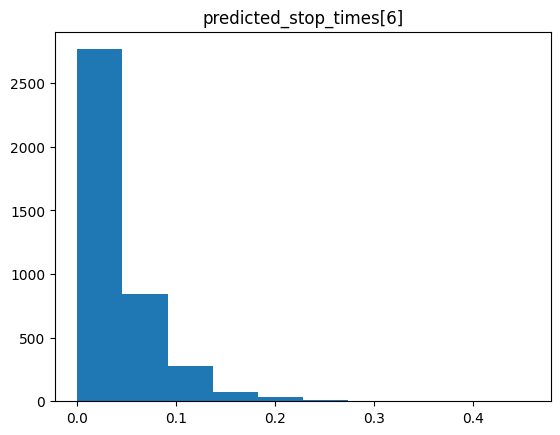

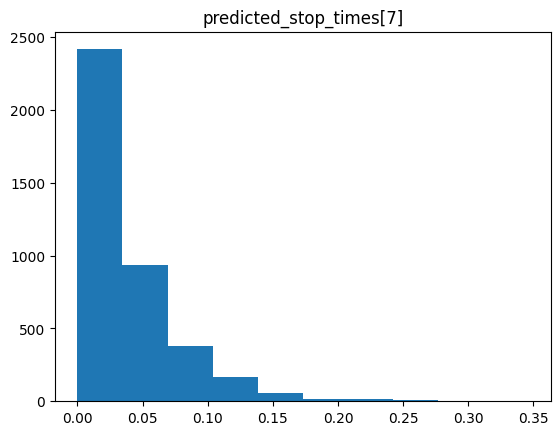

```python
for parameter in ['alpha', 'beta', 'predicted_stop_times[1]', 'predicted_stop_times[2]', 'predicted_stop_times[3]',
               'predicted_stop_times[4]', 'predicted_stop_times[5]', 'predicted_stop_times[6]', 'predicted_stop_times[7]']:
   plt.hist(exp_fit_df[parameter])
   plt.title(parameter)
   plt.show()
```

## 7. Models comparison

```
WAIC
====================================================================================================
```

|  | rank | elpd_waic | p_waic | elpd_diff | weight | se | dse | warning | scale |
| --- | --- | --- | --- | --- | --- | --- | --- | --- | --- |
| Model 1 | 0 | 249.615919 | 4.674397 | 0.000000 | 1.0 | 18.189997 | 0.000000 | True | log |
| Model 2 | 1 | 238.330252 | 3.049154 | 11.285667 | 0.0 | 16.413423 | 3.574024 | True | log |

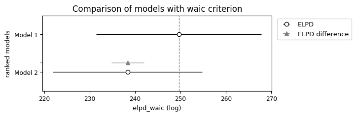

```
====================================================================================================




LOO
====================================================================================================
```

|  | rank | elpd_loo | p_loo | elpd_diff | weight | se | dse | warning | scale |
| --- | --- | --- | --- | --- | --- | --- | --- | --- | --- |
| Model 1 | 0 | 249.451075 | 4.839241 | 0.000000 | 1.0 | 18.266306 | 0.000000 | False | log |
| Model 2 | 1 | 238.315720 | 3.063687 | 11.135355 | 0.0 | 16.419863 | 3.594431 | False | log |

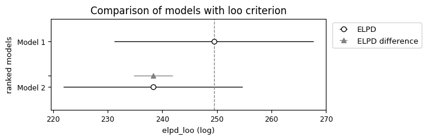

```python
compare_dict = {
    "Model 1": az.from_cmdstanpy(posterior=gamma_fit_sim),
    "Model 2": az.from_cmdstanpy(posterior=exp_fit_sim)
}

for information_criteria in ["waic", "loo"]:
    diff = az.compare(compare_dict=compare_dict, ic=information_criteria)
    print(f"{information_criteria.upper()}")
    print("="*100)
    display(diff)
    ax = az.plot_compare(diff)
    ax.set_title(f"Comparison of models with {information_criteria} criterion")
    plt.show()
    print("="*100)

    if information_criteria == "waic":
        print('\n\n\n')
```